# GuestLecture_ANOVA_Markdown

Jessica Macaluso

2025-02-04

## Data Storytelling: The Fundamentals of Data Visualization with ggplot2

We will be exploring the education data set that was retrieved from kaggle.com (https://www.kaggle.com/datasets/desalegngeb/students-exam-scores?resource=download).

## 1. Load Packages

```r
library(tidyverse)
```

```r
library(visdat)
library(corrplot)
```

## 2. Read in Data

```r
education <- read.csv("education.csv")
head(education)
```

```
##   student_ID Gender EthnicGroup         ParentEduc    LunchType TestPrep
## 1          0 female        <NA>  bachelor's degree     standard     none
## 2          1 female     group C       some college     standard     <NA>
## 3          2 female     group B    master's degree     standard     none
## 4          3   male     group A associate's degree free/reduced     none
## 5          4   male     group C       some college     standard     none
## 6          5 female     group B associate's degree     standard     none
##   ParentMaritalStatus PracticeSport IsFirstChild NrSiblings TransportMeans
## 1             married     regularly          yes          3     school_bus
## 2             married     sometimes          yes          0           <NA>
## 3              single     sometimes          yes          4     school_bus
## 4             married         never           no          1           <NA>
## 5             married     sometimes          yes          0     school_bus
## 6             married     regularly          yes          1     school_bus
##   WklyStudyHours MathScore ReadingScore WritingScore School
## 1            < 5        71           71           74      1
## 2        5 to 10        69           90           88      1
## 3            < 5        87           93           91      1
## 4        5 to 10        45           56           42      1
## 5        5 to 10        76           78           75      1
## 6        5 to 10        73           84           79      1
```

## 3. Overview of Data

```r
nrow(education)
```

```
## [1] 30641
```

```r
ncol(education)
```

```
## [1] 16
```

```r
education %>% map_dbl(~sum( is.na(.) ) ) %>% sum()
```

```
## [1] 13901
```

30641 rows, 16 columns, and 13901 missing values.

## 4. Missingness

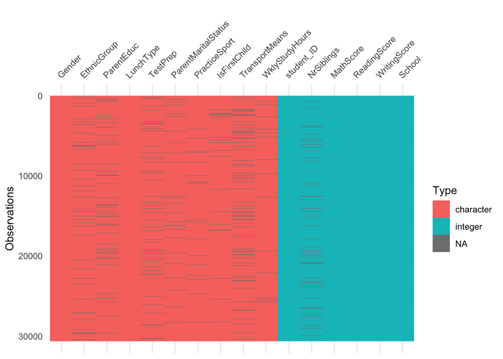

```r
vis_dat(education)
```

## 5. Data Dictionary

- Gender: Gender of the student (2 categories: male or female)
- EthnicGroup: Ethnic group of the student (5 categories: group A, group B, group C, group D, group E)
- ParentEduc: Parent(s) education background (6 categories: some high school, high school, some college, associate’s degree, bachelor’s degree, master’s degree)
- LunchType: School lunch type (2 categories: standard or free/reduced)
- TestPrep: Test preparation course followed (2 categories: none or completed)
- ParentMaritalStatus: Parent(s) marital status (4 categories: single, married, widowed, divorced)
- PracticeSport: How often the student practice sport (3 categories: sometimes, regularly, never)
- IsFirstChild: If the child is first child in the family or not (2 categories: yes or no)
- NrSiblings: Number of siblings the student has (8 categories: 0, 1, 2, 3, 4, 5, 6, 7)
- TransportMeans: Means of transport to school (2 categories: school bus or private)
- WklyStudyHours: Weekly self-study hours (3 categories: less that 5 hours, between 5 and 10 hours, or more than 10 hours)
- MathScore: Math test score (0-100)
- ReadingScore: Reading test score (0-100)
- WritingScore: Writing test score (0-100)
- School: 31 schools (31 categories: 1-31)

## 6. Change Datatypes

```r
education %>% mutate(student_ID = as.factor(student_ID),
                     Gender = as.factor(Gender),
                     EthnicGroup = as.factor(EthnicGroup),
                     ParentEduc = as.factor(ParentEduc),
                     LunchType = as.factor(LunchType),
                     TestPrep = as.factor(TestPrep),
                     ParentMaritalStatus = as.factor(ParentMaritalStatus),
                     PracticeSport = as.factor(PracticeSport),
                     IsFirstChild = as.factor(IsFirstChild),
                     NrSiblings = as.factor(NrSiblings),
                     TransportMeans = as.factor(TransportMeans),
                     WklyStudyHours = as.factor(WklyStudyHours),
                     MathScore = as.numeric(MathScore),
                     ReadingScore = as.numeric(ReadingScore),
                     WritingScore = as.numeric(WritingScore),
                     School = as.factor(School)) -> education
glimpse(education)
```

```
## Rows: 30,641
## Columns: 16
## $ student_ID          <fct> 0, 1, 2, 3, 4, 5, 6, 7, 8, 9, 10, 11, 12, 13, 14, …
## $ Gender              <fct> female, female, female, male, male, female, female…
## $ EthnicGroup         <fct> NA, group C, group B, group A, group C, group B, g…
## $ ParentEduc          <fct> bachelor's degree, some college, master's degree, …
## $ LunchType           <fct> standard, standard, standard, free/reduced, standa…
## $ TestPrep            <fct> none, NA, none, none, none, none, completed, none,…
## $ ParentMaritalStatus <fct> married, married, single, married, married, marrie…
## $ PracticeSport       <fct> regularly, sometimes, sometimes, never, sometimes,…
## $ IsFirstChild        <fct> yes, yes, yes, no, yes, yes, no, yes, no, yes, yes…
## $ NrSiblings          <fct> 3, 0, 4, 1, 0, 1, 1, 1, 3, NA, 1, 1, 1, 1, 2, 0, 0…
## $ TransportMeans      <fct> school_bus, NA, school_bus, NA, school_bus, school…
## $ WklyStudyHours      <fct> < 5, 5 to 10, < 5, 5 to 10, 5 to 10, 5 to 10, 5 to…
## $ MathScore           <dbl> 71, 69, 87, 45, 76, 73, 85, 41, 65, 37, 58, 40, 66…
## $ ReadingScore        <dbl> 71, 90, 93, 56, 78, 84, 93, 43, 64, 59, 54, 52, 82…
## $ WritingScore        <dbl> 74, 88, 91, 42, 75, 79, 89, 39, 68, 50, 52, 43, 74…
## $ School              <fct> 1, 1, 1, 1, 1, 1, 1, 1, 1, 1, 1, 1, 1, 1, 1, 1, 1,…
```

Now all categorical variables are factors and all continuous variables are numeric.

## 7. Categorical Variables (Simple Bar Chart)

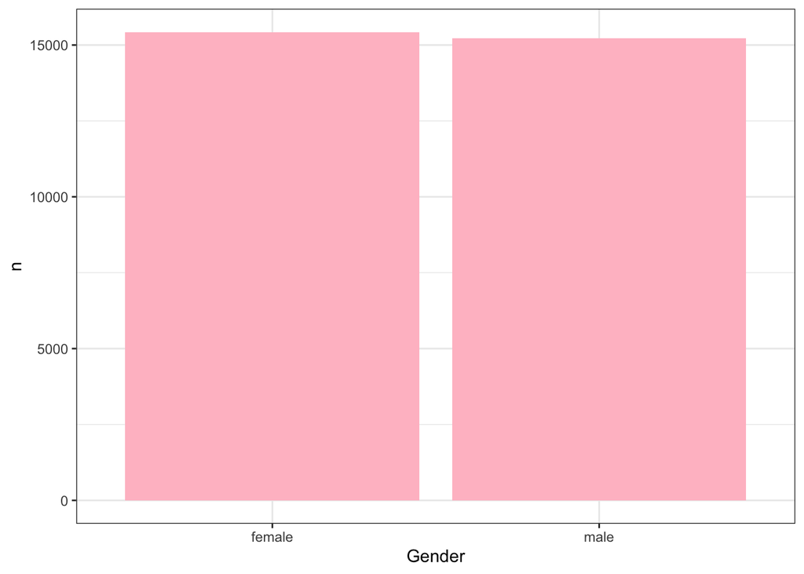

```r
education %>% count(Gender) %>%
  ggplot(mapping = aes(x = Gender, y = n)) +
  geom_col(fill = 'pink') +
  theme_bw()
```

## 8. Categorical Variables (Stacked Bar Chart)

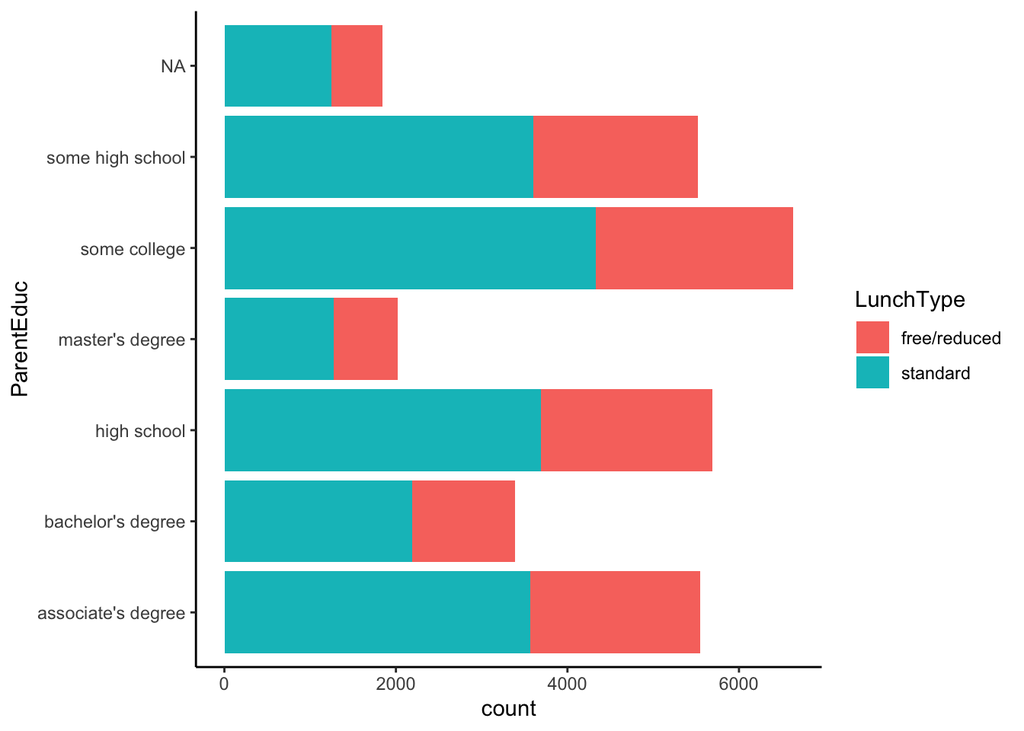

```r
education %>%
  ggplot(mapping = aes(y = ParentEduc)) +
  geom_bar(mapping = aes(fill = LunchType)) +
  theme_classic()
```

## 9. Categorical Variables (Dodged Bar Chart)

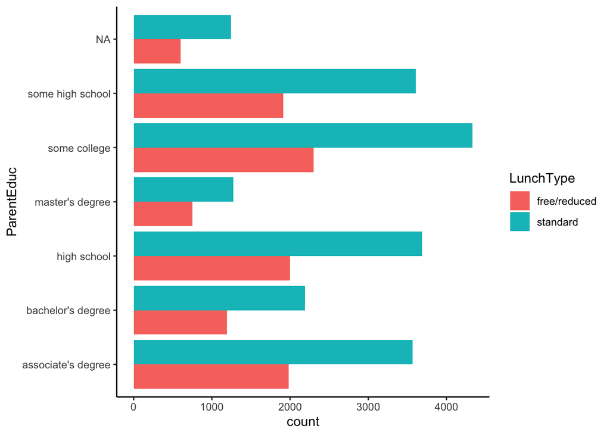

```r
education %>%
  ggplot(mapping = aes(y = ParentEduc)) +
  geom_bar(mapping = aes(fill = LunchType), position = 'dodge') +
  theme_classic()
```

## 10. Categorical Variables (Heat Map)

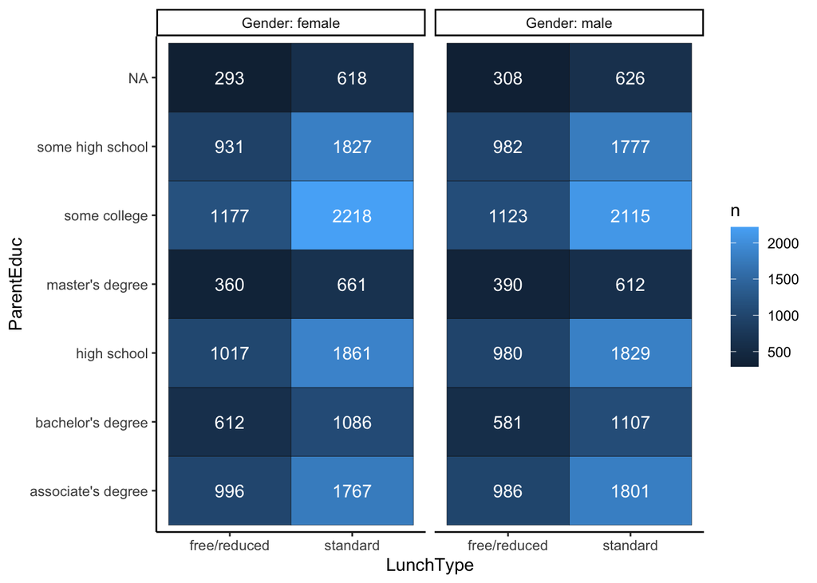

```r
education %>%
  count(ParentEduc, LunchType, Gender) %>%
  ggplot (mapping = aes(x = LunchType, y = ParentEduc)) +
  geom_tile(mapping = aes(fill = n),
            color = "black") +
  facet_wrap(~ Gender, labeller = 'label_both') +
  geom_text(mapping = aes(label = n), color = 'white') +
  theme_classic()
```

## 11. Continuous Variables (Histogram)

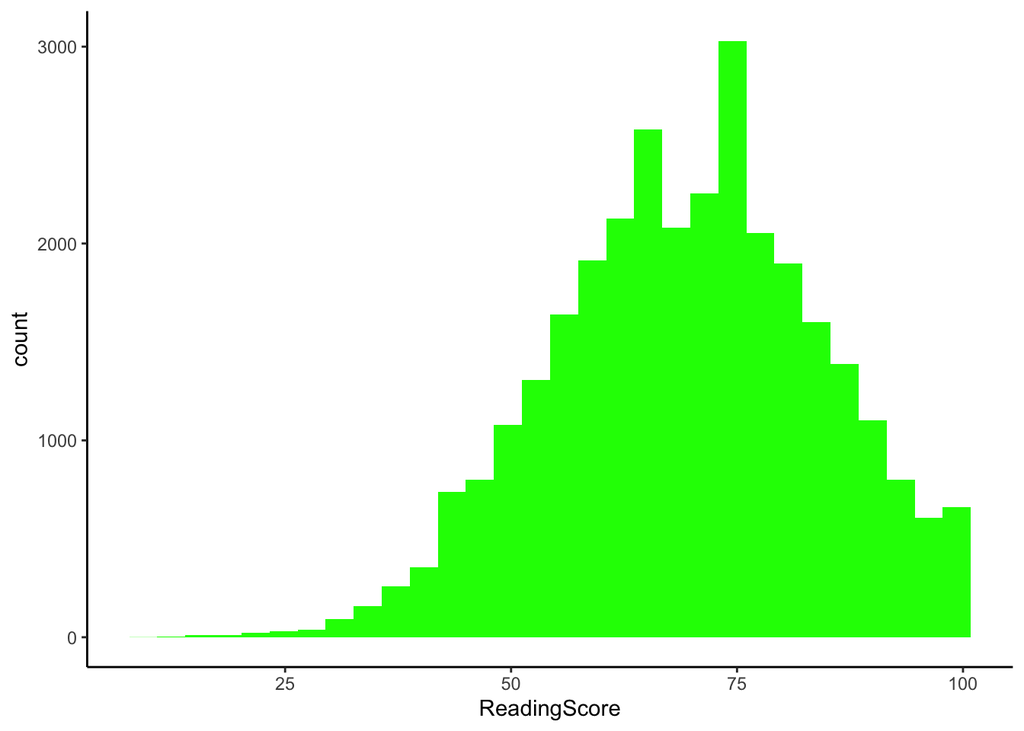

```r
education %>%
  ggplot(mapping = aes(x = ReadingScore)) +
  geom_histogram(bins = 30, fill = 'green') +
  theme_classic()
```

## 12. Continuous Variables (Density Plot)

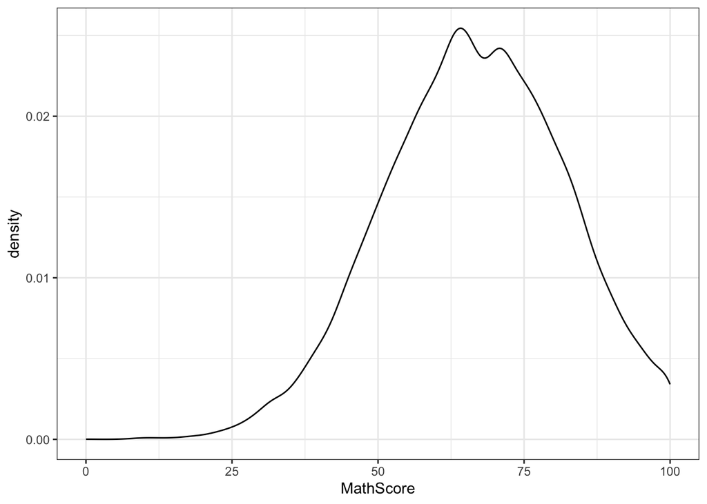

```r
education %>%
  ggplot(mapping = aes(x = MathScore)) +
  geom_density() +
  theme_bw()
```

## 13. Continuous Variables (Histogram + Density Plot)

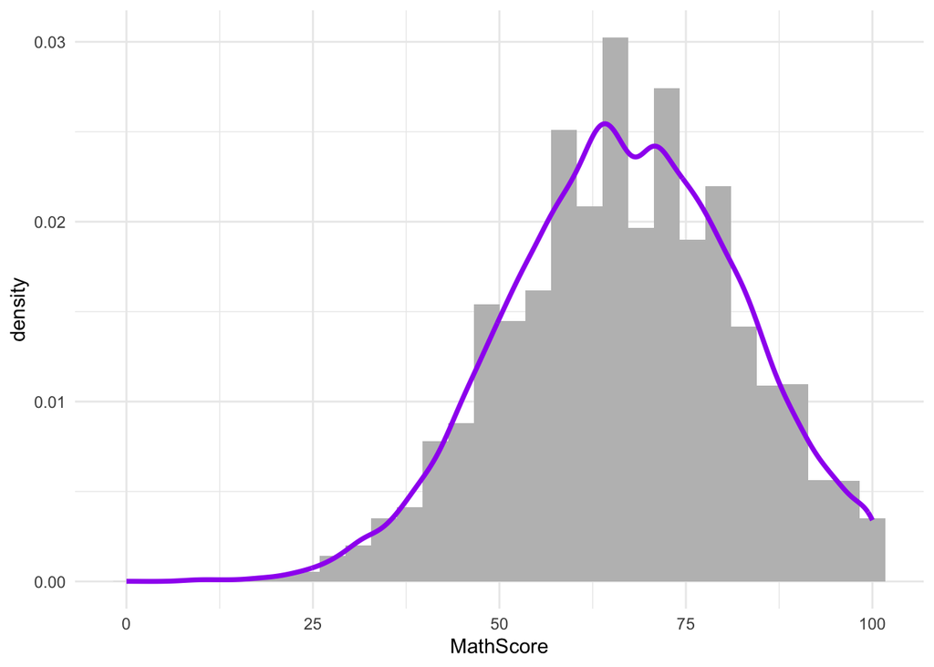

```r
education %>%
  ggplot(mapping = aes(x = MathScore)) +
  geom_histogram(bins = 30, fill = 'grey', mapping = aes(y = after_stat(density))) +
  geom_density(color = 'purple', linewidth = 1.25) +
  theme_minimal()
```

## 14. Continuous Variables (Scatterplot)

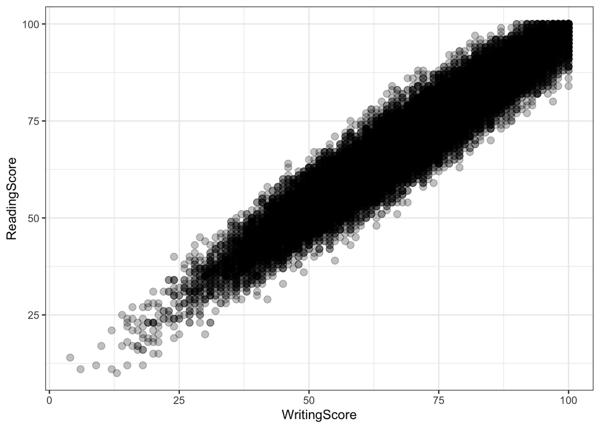

```r
education %>%
  ggplot(mapping = aes(x = WritingScore, y = ReadingScore)) +
  geom_point(size = 2.5 , alpha = .25) +
  theme_bw()
```

## 15. Continuous Variables (Correlation Plot)

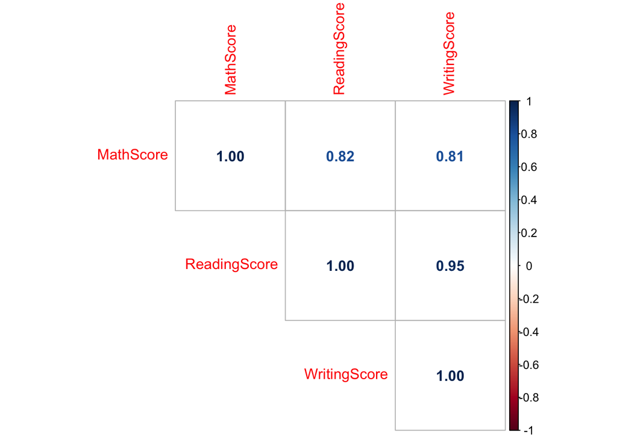

```r
education %>%
  select(MathScore, ReadingScore, WritingScore) %>%
  cor() %>%
  corrplot::corrplot(method = 'number', type = 'upper')
```

## 16. Categorical + Continuous Variables (Boxplot)

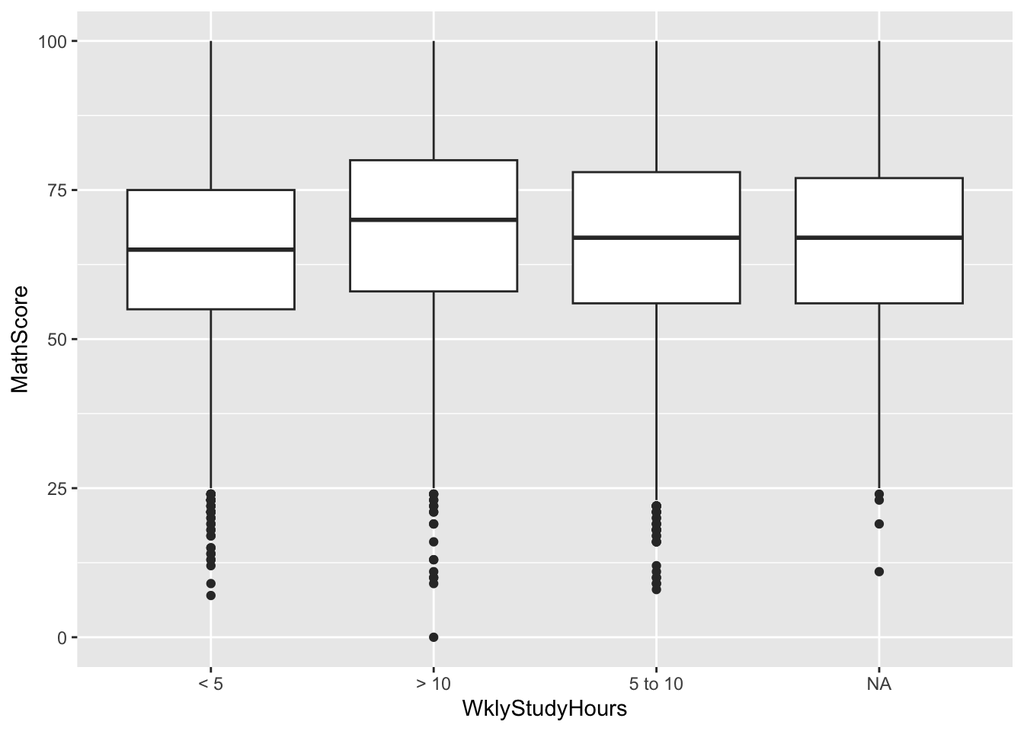

```r
education %>%
  ggplot(mapping = aes(x = WklyStudyHours, y = MathScore)) +
  geom_boxplot()
```

## 17. Categorical + Continuous Variables (Violin Plot)

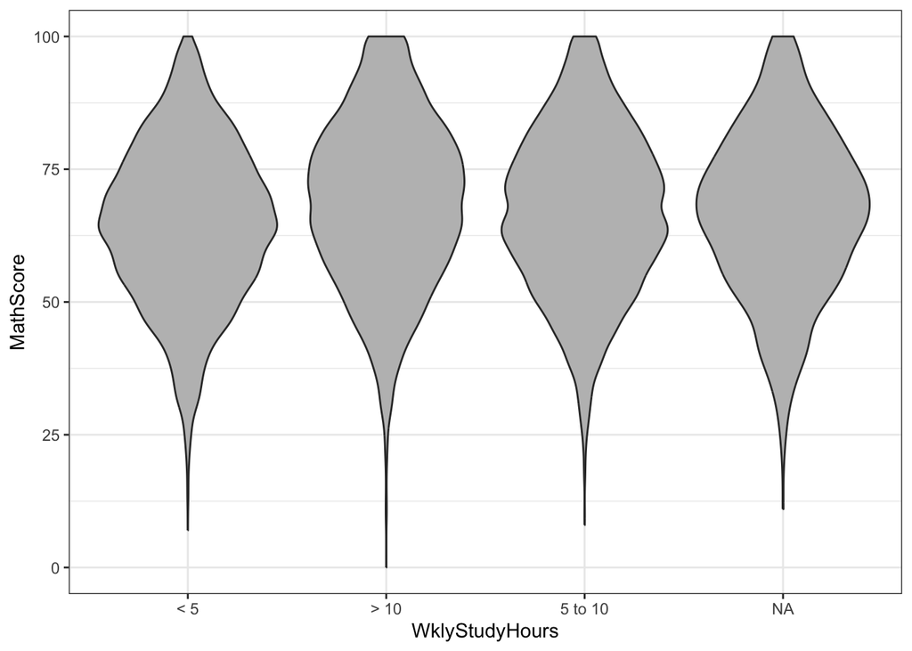

```r
education %>%
  ggplot(mapping = aes(x = WklyStudyHours, y = MathScore)) +
  geom_violin(fill = 'grey') +
  theme_bw()
```

## 18. Categorical + Continuous Variables (Scatterplot)

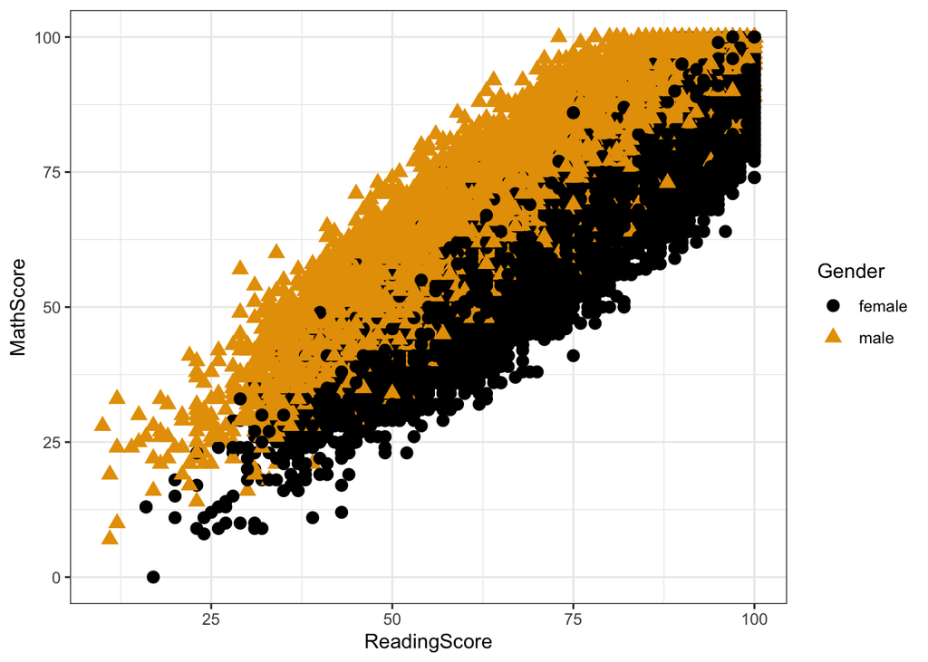

```r
education %>%
  ggplot(mapping = aes(x = ReadingScore, y = MathScore)) +
  geom_point(mapping = aes(color = Gender, shape = Gender), size = 3) +
  ggthemes::scale_color_colorblind() +
  theme_bw()
```

## 19. Categorical + Continuous Variables (Heat Map)

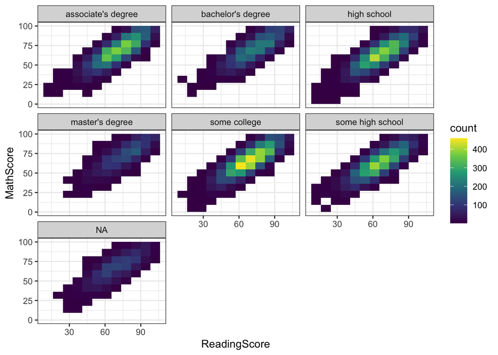

```r
education %>%
  ggplot(mapping = aes(x = ReadingScore, y = MathScore)) +
  geom_bin_2d(bins = 11) +
  facet_wrap(~ ParentEduc) +
  scale_fill_viridis_c() +
  theme_bw()
```